# HW2

## 1.Introduction

The question I will try to answer through my research is “Are Airline company revenues, travel agency revenues and rental car revenues related?” The data is collected monthly from 01.2017 to 12.2019 *The recorded data is composed of debit and credit card purchases

## 2.Plots

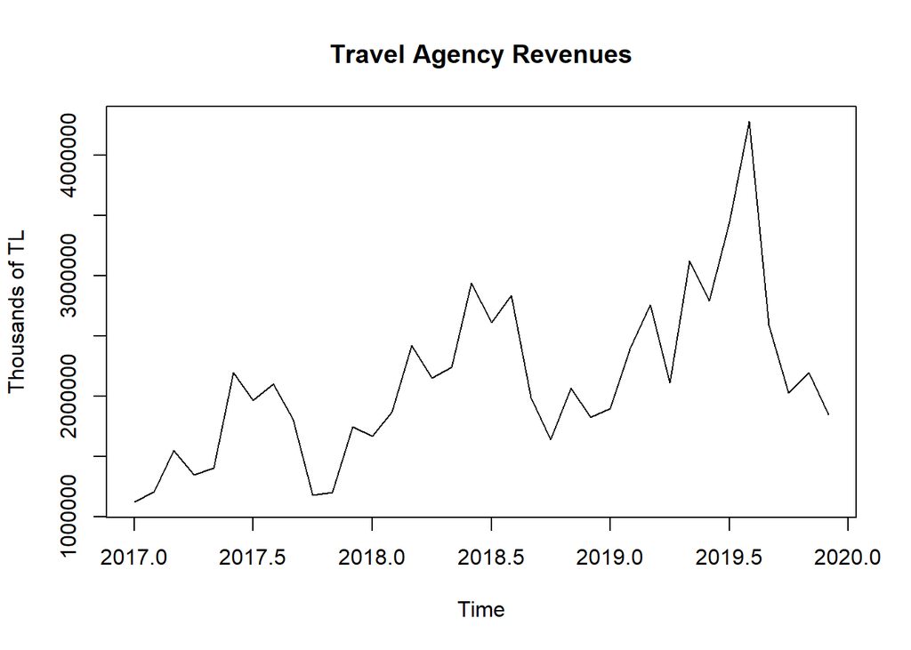

```r
plot(AgencyTS, ylab="Thousands of TL", main="Travel Agency Revenues")
```

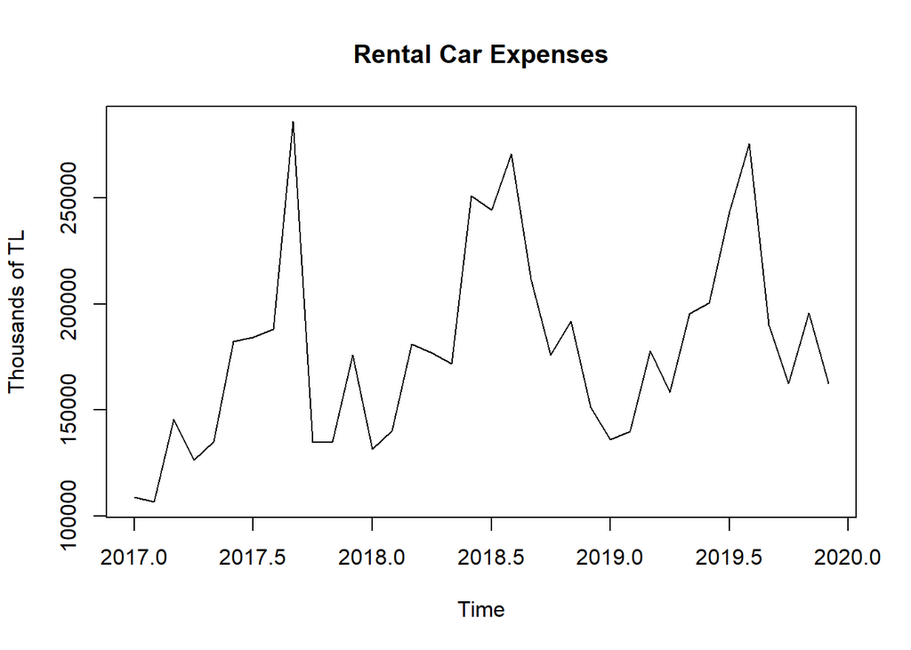

```r
plot(CarRentts, ylab="Thousands of TL", main="Rental Car Expenses")
```

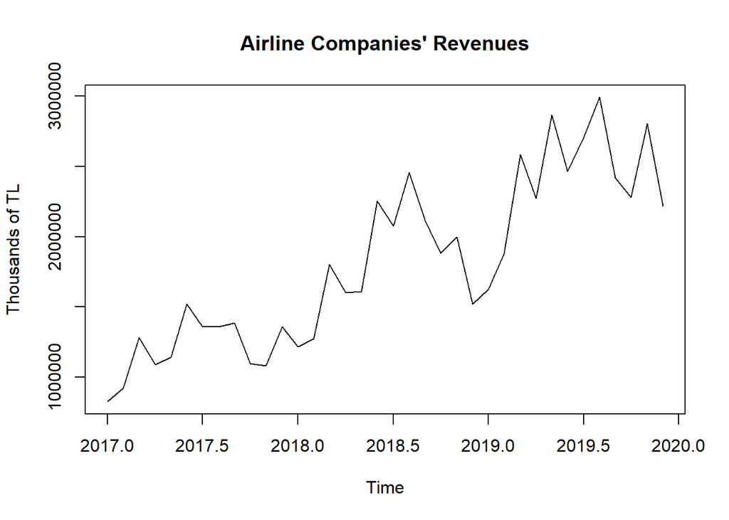

```r
plot(AirlineTS, ylab="Thousands of TL", main="Airline Companies' Revenues")
```

## 3. Conclusion

As one would expect each year there are spikes during the summer season,not to be confused;these plots don’t mean that one is necessarily caused by the other two,it just shows some degree of correlation.We could attribute this to the fact that most working people use their yearly leave during this period which leads to more spending on travel.

## 4. Appendix

Car Rents(in thousands of TL)

CarRents <- c(108936, 106580, 145577, 126405, 135054, 182248, 184279, 188031, 286074, 134649, 134736, 175923, 131587, 140348, 181225, 176923, 171746, 251013, 244322, 270997, 211721, 176074, 191844, 151419, 136119, 139989, 177885, 158321, 195371, 200613, 243696, 275759, 190067, 162417, 195692, 162640)

CarRentts <- ts(CarRents, start=c(2017, 1), end=c(2019, 12), frequency=12)

Airline Companies revenues

Airline <- c(825752, 921998, 1280648, 1087579, 1142986, 1519731, 1359263, 1357882, 1387055, 1094803, 1080340, 1357898, 1216894, 1273761, 1803113, 1600546, 1609882, 2254828, 2075236, 2456916, 2117761, 1882361, 1999645, 1519238, 1623085, 1877966, 2583398, 2271501, 2865950, 2467060, 2706922, 2992024, 2419583, 2278637, 2806130, 2219046)

AirlineTS <- ts(Airline, start=c(2017, 1), end=c(2019, 12), frequency=12)

Travel Agency revenues

Agency <-c (1124445, 1207388, 1551244, 1352320, 1406880, 2198421, 1969959, 2101346, 1809660, 1182177, 1202259, 1747449, 1671645, 1873107, 2422083, 2154303, 2239771, 2940114, 2613974, 2837925, 1989865, 1643213, 2067292, 1825230, 1898557, 2396438, 2761069, 2114515, 3121000, 2792991, 3450350, 4276892, 2591385, 2030298, 2194814, 1849200)

AgencyTS <- ts(Agency, start=c(2017, 1), end=c(2019, 12), frequency=12)